# Mohammed Adeen Shaik_8969152_Midterm

## **CSCN8000 –Artificial Intelligence Algorithms and Mathematics**

### **MID TERM - LOGISTIC REGRESSION**

#### Student Name: **Mohammed Adeen Shaik**

#### Student ID: **8969152**

#### **OBJECTIVE:** To Implement and evaluate a Logistic Regression model for credit card fraud detection, covering data preprocessing, feature selection, and model evaluation. Compare its performance with KNN and SVM using key metrics like accuracy, precision, recall, F1-score, and ROC-AUC.

```python
import numpy as np
import pandas as pd
import seaborn as sns
import matplotlib.pyplot as plt
from sklearn.model_selection import train_test_split, cross_val_score
from sklearn.preprocessing import MinMaxScaler, StandardScaler
from scipy.stats import skew
from sklearn.linear_model import LogisticRegression
from sklearn.metrics import accuracy_score, precision_score, recall_score, f1_score, log_loss, roc_curve, auc
from sklearn.neighbors import KNeighborsClassifier
from sklearn.svm import SVC
```

#### **Loading the Credit card data**

**Source: *[Credit Card Fraud Detection on Kaggle](https://www.kaggle.com/datasets/mlg-ulb/creditcardfraud/data)***

```python
credit = pd.read_csv('creditcard.csv')

credit.head(5)
```

|  | Time | V1 | V2 | V3 | V4 | V5 | V6 | V7 | V8 | V9 | ... | V21 | V22 | V23 | V24 | V25 | V26 | V27 | V28 | Amount | Class |
| --- | --- | --- | --- | --- | --- | --- | --- | --- | --- | --- | --- | --- | --- | --- | --- | --- | --- | --- | --- | --- | --- |
| 0 | 0.0 | -1.359807 | -0.072781 | 2.536347 | 1.378155 | -0.338321 | 0.462388 | 0.239599 | 0.098698 | 0.363787 | ... | -0.018307 | 0.277838 | -0.110474 | 0.066928 | 0.128539 | -0.189115 | 0.133558 | -0.021053 | 149.62 | 0 |
| 1 | 0.0 | 1.191857 | 0.266151 | 0.166480 | 0.448154 | 0.060018 | -0.082361 | -0.078803 | 0.085102 | -0.255425 | ... | -0.225775 | -0.638672 | 0.101288 | -0.339846 | 0.167170 | 0.125895 | -0.008983 | 0.014724 | 2.69 | 0 |
| 2 | 1.0 | -1.358354 | -1.340163 | 1.773209 | 0.379780 | -0.503198 | 1.800499 | 0.791461 | 0.247676 | -1.514654 | ... | 0.247998 | 0.771679 | 0.909412 | -0.689281 | -0.327642 | -0.139097 | -0.055353 | -0.059752 | 378.66 | 0 |
| 3 | 1.0 | -0.966272 | -0.185226 | 1.792993 | -0.863291 | -0.010309 | 1.247203 | 0.237609 | 0.377436 | -1.387024 | ... | -0.108300 | 0.005274 | -0.190321 | -1.175575 | 0.647376 | -0.221929 | 0.062723 | 0.061458 | 123.50 | 0 |
| 4 | 2.0 | -1.158233 | 0.877737 | 1.548718 | 0.403034 | -0.407193 | 0.095921 | 0.592941 | -0.270533 | 0.817739 | ... | -0.009431 | 0.798278 | -0.137458 | 0.141267 | -0.206010 | 0.502292 | 0.219422 | 0.215153 | 69.99 | 0 |

5 rows × 31 columns

```python
credit.describe()
```

|  | Time | V1 | V2 | V3 | V4 | V5 | V6 | V7 | V8 | V9 | ... | V21 | V22 | V23 | V24 | V25 | V26 | V27 | V28 | Amount | Class |
| --- | --- | --- | --- | --- | --- | --- | --- | --- | --- | --- | --- | --- | --- | --- | --- | --- | --- | --- | --- | --- | --- |
| count | 284807.000000 | 2.848070e+05 | 2.848070e+05 | 2.848070e+05 | 2.848070e+05 | 2.848070e+05 | 2.848070e+05 | 2.848070e+05 | 2.848070e+05 | 2.848070e+05 | ... | 2.848070e+05 | 2.848070e+05 | 2.848070e+05 | 2.848070e+05 | 2.848070e+05 | 2.848070e+05 | 2.848070e+05 | 2.848070e+05 | 284807.000000 | 284807.000000 |
| mean | 94813.859575 | 1.168375e-15 | 3.416908e-16 | -1.379537e-15 | 2.074095e-15 | 9.604066e-16 | 1.487313e-15 | -5.556467e-16 | 1.213481e-16 | -2.406331e-15 | ... | 1.654067e-16 | -3.568593e-16 | 2.578648e-16 | 4.473266e-15 | 5.340915e-16 | 1.683437e-15 | -3.660091e-16 | -1.227390e-16 | 88.349619 | 0.001727 |
| std | 47488.145955 | 1.958696e+00 | 1.651309e+00 | 1.516255e+00 | 1.415869e+00 | 1.380247e+00 | 1.332271e+00 | 1.237094e+00 | 1.194353e+00 | 1.098632e+00 | ... | 7.345240e-01 | 7.257016e-01 | 6.244603e-01 | 6.056471e-01 | 5.212781e-01 | 4.822270e-01 | 4.036325e-01 | 3.300833e-01 | 250.120109 | 0.041527 |
| min | 0.000000 | -5.640751e+01 | -7.271573e+01 | -4.832559e+01 | -5.683171e+00 | -1.137433e+02 | -2.616051e+01 | -4.355724e+01 | -7.321672e+01 | -1.343407e+01 | ... | -3.483038e+01 | -1.093314e+01 | -4.480774e+01 | -2.836627e+00 | -1.029540e+01 | -2.604551e+00 | -2.256568e+01 | -1.543008e+01 | 0.000000 | 0.000000 |
| 25% | 54201.500000 | -9.203734e-01 | -5.985499e-01 | -8.903648e-01 | -8.486401e-01 | -6.915971e-01 | -7.682956e-01 | -5.540759e-01 | -2.086297e-01 | -6.430976e-01 | ... | -2.283949e-01 | -5.423504e-01 | -1.618463e-01 | -3.545861e-01 | -3.171451e-01 | -3.269839e-01 | -7.083953e-02 | -5.295979e-02 | 5.600000 | 0.000000 |
| 50% | 84692.000000 | 1.810880e-02 | 6.548556e-02 | 1.798463e-01 | -1.984653e-02 | -5.433583e-02 | -2.741871e-01 | 4.010308e-02 | 2.235804e-02 | -5.142873e-02 | ... | -2.945017e-02 | 6.781943e-03 | -1.119293e-02 | 4.097606e-02 | 1.659350e-02 | -5.213911e-02 | 1.342146e-03 | 1.124383e-02 | 22.000000 | 0.000000 |
| 75% | 139320.500000 | 1.315642e+00 | 8.037239e-01 | 1.027196e+00 | 7.433413e-01 | 6.119264e-01 | 3.985649e-01 | 5.704361e-01 | 3.273459e-01 | 5.971390e-01 | ... | 1.863772e-01 | 5.285536e-01 | 1.476421e-01 | 4.395266e-01 | 3.507156e-01 | 2.409522e-01 | 9.104512e-02 | 7.827995e-02 | 77.165000 | 0.000000 |
| max | 172792.000000 | 2.454930e+00 | 2.205773e+01 | 9.382558e+00 | 1.687534e+01 | 3.480167e+01 | 7.330163e+01 | 1.205895e+02 | 2.000721e+01 | 1.559499e+01 | ... | 2.720284e+01 | 1.050309e+01 | 2.252841e+01 | 4.584549e+00 | 7.519589e+00 | 3.517346e+00 | 3.161220e+01 | 3.384781e+01 | 25691.160000 | 1.000000 |

8 rows × 31 columns

Before we start, Let me explain some of the columns (features) as described by Kaggle.

- Features **V1, V2, … V28** are the principal components obtained with PCA (Principal Component Analysis), the only features which have not been transformed with PCA are 'Time' and 'Amount'.
- Feature **'Time'** contains the seconds elapsed between each transaction and the first transaction in the dataset.
- feature **'Amount'** is the transaction Amount, this feature can be used for example-dependant cost-sensitive learning.
- Feature **'Class'** is the response variable and it takes value 1 in case of fraud and 0 otherwise.

### *Task 1: Data Preprocessing*

```python
credit.isnull().sum()
```

```
Time      0
V1        0
V2        0
V3        0
V4        0
V5        0
V6        0
V7        0
V8        0
V9        0
V10       0
V11       0
V12       0
V13       0
V14       0
V15       0
V16       0
V17       0
V18       0
V19       0
V20       0
V21       0
V22       0
V23       0
V24       0
V25       0
V26       0
V27       0
V28       0
Amount    0
Class     0
dtype: int64
```

There are no Null Values in the dataset

#### 1.Detecting outliers for all the numerical features in the dataset (Exploring the Data)

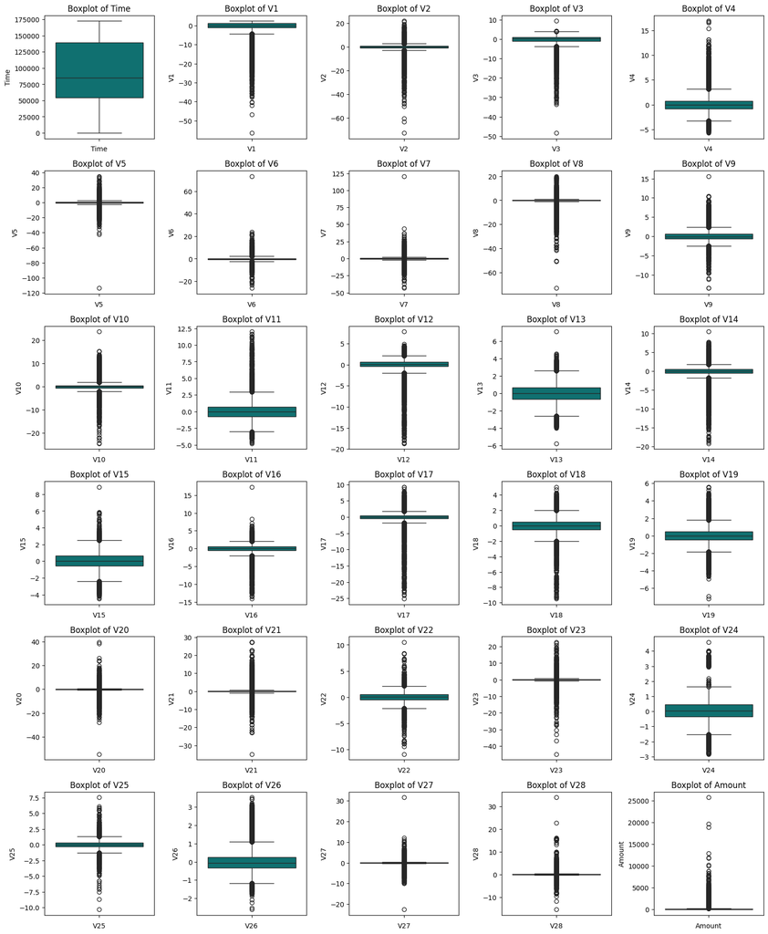

```python
fig, axes = plt.subplots(10, 5, figsize=(16, 32))
axes = axes.ravel()  # Flatten the axes array

# Extract the numeric columns
num_cols = credit.select_dtypes(['int64', 'float64']).columns.tolist()

# Create boxplots for each numeric column

for idx, col in enumerate(num_cols[:-1]): # Removing the last column ("Class") because it is a binary field (Output of two classes 0 and 1) and therefore not needed this step
    sns.boxplot(y=credit[col], ax=axes[idx], color='teal')
    axes[idx].set_title(f'Boxplot of {col}')
    axes[idx].set_xlabel(col)

# Hide any unused subplots
for j in range(len(num_cols[:-1]), len(axes)):
    axes[j].set_visible(False)

plt.tight_layout()
plt.show()
```

- This boxlot Indicates that there is a significant number of outliers in most of the numeric columns
- Given the high count of outliers across multiple columns, the **Whisker’s Method** is the most suitable approach for outlier removal.

```python
cleaned_credit = credit.copy()
for column in cleaned_credit.columns:
    # Ignore class column
    if(column == "Class"):
        continue

    # Calculate Q1 and Q3 for Inter Quartile Range Calculation
    Q1 = credit[column].quantile(0.25)
    Q3 = credit[column].quantile(0.75)
    IQR = Q3 - Q1

    # Define the bounds
    lower_bound = Q1 - 1.5 * IQR
    upper_bound = Q3 + 1.5 * IQR

    # Replace outlier with mean
    mean_replacer = credit[column].mean()
    to_replace = (cleaned_credit[column] < lower_bound) | (cleaned_credit[column] > upper_bound)
    cleaned_credit.loc[to_replace, column] = mean_replacer
```

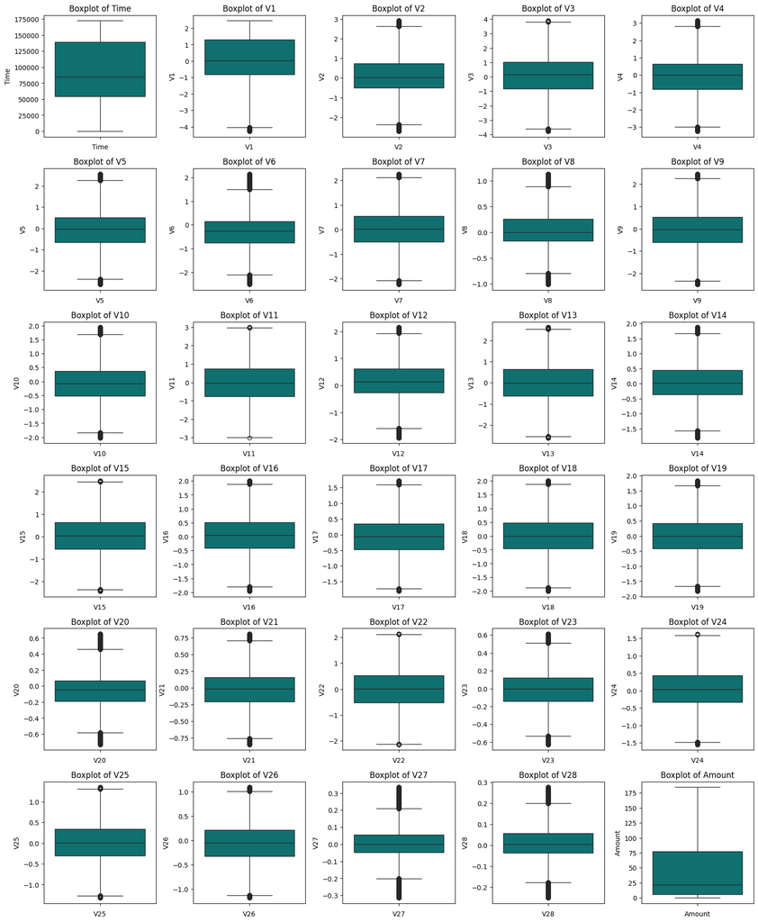

```python
# Reviewing the processed data

fig, axes = plt.subplots(10, 5, figsize=(16, 32))
axes = axes.ravel()  # Flatten the axes array
num_cols = cleaned_credit.select_dtypes(['int64', 'float64']).columns.tolist()


for idx, col in enumerate(num_cols[:-1]):
    sns.boxplot(y=cleaned_credit[col], ax=axes[idx], color='teal')
    axes[idx].set_title(f'Boxplot of {col}')
    axes[idx].set_xlabel(col)

for j in range(len(num_cols[:-1]), len(axes)):
    axes[j].set_visible(False)

plt.tight_layout()
plt.show()
```

Now the Boxplots have a standard shape

- Most of the features appear to have gaussian distribution, therefore they do not require normalizing. But the Time and Amount feature are different.
- The Time feature exhibits multiple peaks, indicating multimodal dstribution. The Amount feature is right-skewed, suggesting a need for transformation.

#### 2. Feature Analysis

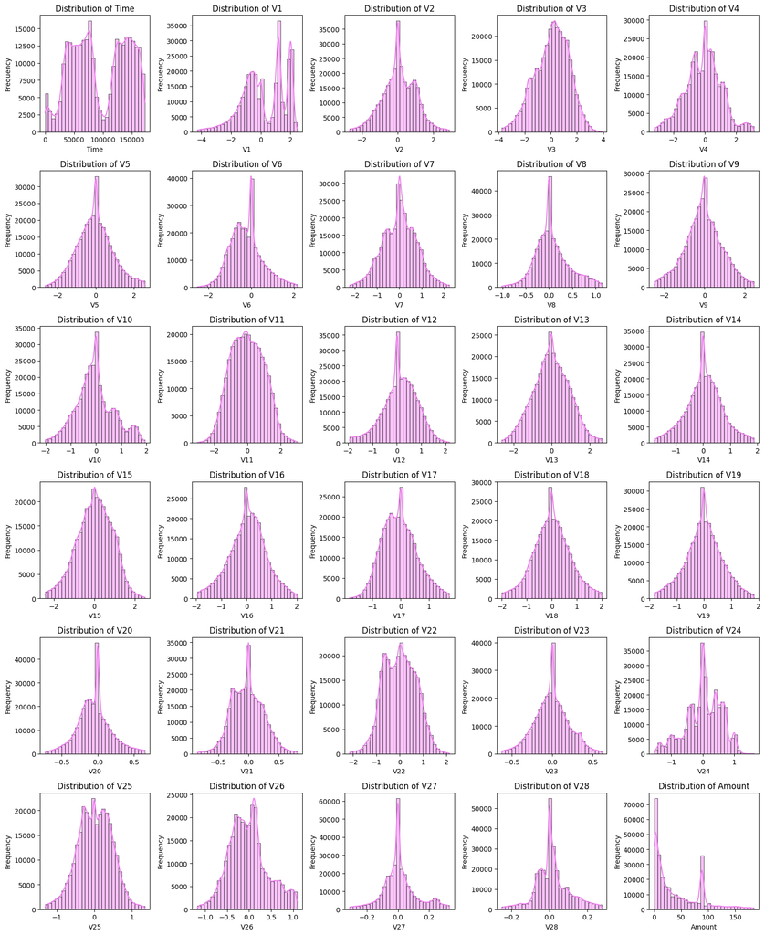

```python
# Set up a grid of subplots
fig, axes = plt.subplots(nrows=10, ncols=5, figsize=(16, 32))
axes = axes.flatten()

numeric_columns = cleaned_credit.select_dtypes(include=['number']).columns

# Iterate over each numeric column to plot its distribution
for idx, col in enumerate(numeric_columns[:-1]):
    # Plot histogram with KDE on each axis
    sns.histplot(data=cleaned_credit, x=col, ax=axes[idx], kde=True, color='violet', bins=30)
    axes[idx].set_title(f'Distribution of {col}')
    axes[idx].set_xlabel(col)
    axes[idx].set_ylabel('Frequency')

# Hide any unused subplots
for idx in range(len(numeric_columns[:-1]), len(axes)):
    axes[idx].set_visible(False)

# Adjust layout to prevent overlap
plt.tight_layout()
plt.show()
```

```python
scaler = MinMaxScaler()
cleaned_credit[['Time', 'Amount']] = scaler.fit_transform(cleaned_credit[['Time', 'Amount']])

print(cleaned_credit[['Time', 'Amount']].head())
```

```
       Time    Amount
0  0.000000  0.810949
1  0.000000  0.014580
2  0.000006  0.478860
3  0.000006  0.669377
4  0.000012  0.379350
```

### *Task 2: Descriptive Analytics*

#### 1. Analyze the distribution of fraud vs non-fraud transactions

As discovered before, The Feature 'Class' is the response variable and it takes value 1 in case of fraud and 0 otherwise.

```python
class_count = cleaned_credit['Class'].value_counts()

# Print  class value counts
print(class_count)
```

```
Class
0    284315
1       492
Name: count, dtype: int64
```

In the data we have 492 frauds out of 284,807 transactions. The dataset is highly unbalanced, the positive class (frauds) account for 0.172% of all transactions.

#### 2.Analyze the correlation between fraud/non-fraud transactions and all the other numerical features.

```python
cleaned_credit['Class'] = cleaned_credit['Class'].astype(int)
# Calculate the correlation matrix
ccorrelation_with_class = cleaned_credit.corr()['Class'].sort_values(ascending=False)

print(ccorrelation_with_class)
```

```
Class     1.000000
V4        0.024471
V2        0.023431
V11       0.022837
V21       0.021066
V20       0.017936
V19       0.011031
V28       0.006058
V8        0.005329
V17       0.004942
V25       0.004776
V26       0.004064
V27       0.001076
V22       0.000906
Amount   -0.000161
V10      -0.000953
V15      -0.001967
V13      -0.003777
V16      -0.004887
V14      -0.005152
V23      -0.005640
V18      -0.006018
V5       -0.007402
V24      -0.008953
V7       -0.010452
V12      -0.010551
Time     -0.012323
V3       -0.018549
V9       -0.019105
V6       -0.023334
V1       -0.023542
Name: Class, dtype: float64
```

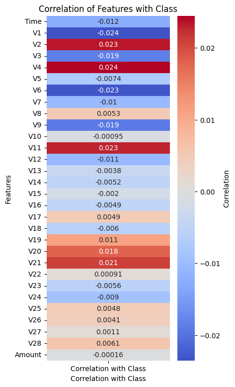

```python
correlation_with_class = cleaned_credit.corr()['Class'].drop('Class')  # Drop 'Class' itself
# Convert the series to a DataFrame for easier plotting
correlation_df = correlation_with_class.to_frame().reset_index()
correlation_df.columns = ['Feature', 'Correlation with Class']

# Plot heatmap
plt.figure(figsize=(4, len(correlation_df) * 0.3))  # Adjust figure size for vertical orientation
sns.heatmap(correlation_df.set_index('Feature'), annot=True, cmap='coolwarm', center=0, cbar_kws={'label': 'Correlation'})
plt.title('Correlation of Features with Class')
plt.ylabel('Features')
plt.xlabel('Correlation with Class')
plt.show()
```

From the above Given Correlation Table of all features with respect to **'Class**', It is observed that:

Overall Top 10 features are: **V4, V1, V2, V6, V11, V21, V3, V9, V20, Time**

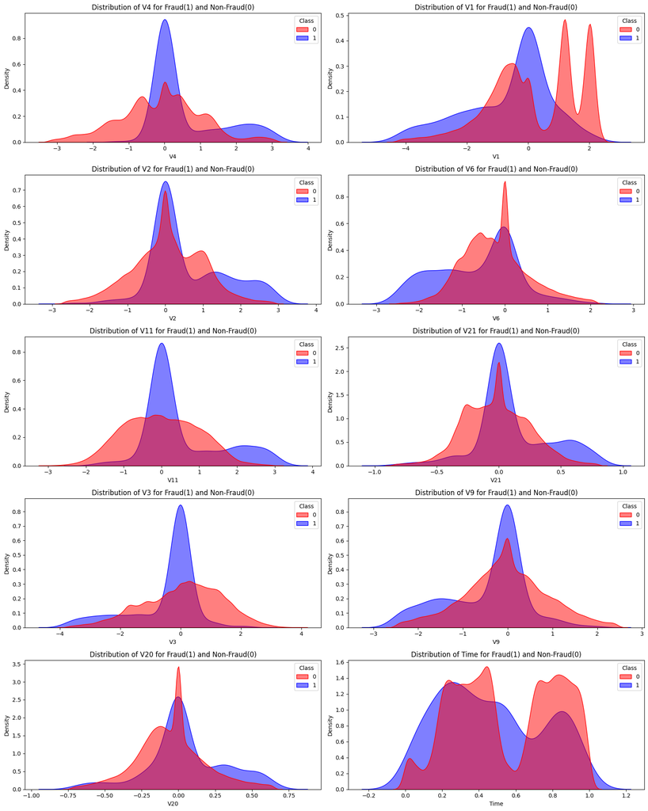

```python
top_features = ['V4', 'V1', 'V2', 'V6', 'V11', 'V21', 'V3', 'V9', 'V20', 'Time']

# create subplots
fig, axes = plt.subplots(nrows=5, ncols=2, figsize=(16, 20))
axes = axes.flatten()

sns.set_palette(["red", "blue"])

for i, column in enumerate(top_features):
    sns.kdeplot(data=cleaned_credit, x=column, hue='Class', fill=True, common_norm=False, alpha=0.5, ax=axes[i])
    axes[i].set_title(f'Distribution of {column} for Fraud(1) and Non-Fraud(0)')
    axes[i].set_xlabel(column)
    axes[i].set_ylabel('Density')

plt.tight_layout()
plt.show()
```

### *Task 3: ML Model Training and Testing*

1. Splitting **Cleaned** data for training and testing:

```python
X = cleaned_credit.drop(columns=['Class'])
y = cleaned_credit['Class']
X_train, X_test, y_train, y_test = train_test_split(X, y, test_size=0.2, random_state=42, stratify=y)

print("Training set size:", X_train.shape)
print("Testing set size:", X_test.shape)
```

```
Training set size: (227845, 30)
Testing set size: (56962, 30)
```

2. Using 5-fold cross-validation to train and validate the performance of all the models

```python
# There are three models in this section:
# 1. Logistic Regression
# 2. KNN
# 3. SVM

# Apply scaling because later on when we use the other models, the KNN and SVM performance react highly to the scale
scaler = StandardScaler()
X_scaled = scaler.fit_transform(X)

logreg = LogisticRegression(max_iter=1000)
logreg_scores = cross_val_score(logreg, X_scaled, y, cv=5)
print(f"Logistic Regression Accuracy: {logreg_scores.mean():.4f}")
```

```
Logistic Regression Accuracy: 0.9983
```

```python
# KNN
knn = KNeighborsClassifier()
knn_scores = cross_val_score(knn, X_scaled, y, cv=5)
print(f"\nKNN Accuracy: {knn_scores.mean():.4f}")
```

```
KNN Accuracy: 0.9984
```

```python
#SVM
svm = SVC()
svm_scores = cross_val_score(svm, X_scaled, y, cv=5)
print(f"\nSVM Accuracy: {svm_scores.mean():.4f}")
```

```
SVM Accuracy: 0.9986
```

3. Train a logistic regression model as a baseline model.

```python
logreg = LogisticRegression(max_iter=1000)

# Model Fitting
logreg.fit(X_train, y_train)
```

```
LogisticRegression(max_iter=1000)
```

4. Print the Learned Coefficients:

```python
coefficients = logreg.coef_[0]
feature_names = X.columns
coeff_df = pd.DataFrame(coefficients, index=feature_names, columns=["Coefficient"])
print("Learned Coefficients (Weights) of the Model:")
print(coeff_df)
```

```
Learned Coefficients (Weights) of the Model:
        Coefficient
Time      -1.852776
V1        -0.226933
V2         0.413301
V3        -0.513346
V4         0.612808
V5        -0.450222
V6        -0.998549
V7        -0.689110
V8         0.232559
V9        -0.530295
V10       -0.213116
V11        0.523288
V12       -0.770959
V13       -0.110520
V14       -0.859244
V15       -0.475205
V16       -0.926134
V17       -1.055298
V18       -0.478586
V19        0.472231
V20        1.136731
V21        1.424769
V22       -0.340155
V23       -0.158335
V24       -0.929161
V25        0.063390
V26        0.700907
V27       -0.109879
V28        0.066213
Amount    -0.666564
```

5. Evaluate the model's performance on the test set

```python
y_pred = logreg.predict(X_test)

# Performance Metrics
metrics1 = {
    "Accuracy": accuracy_score(y_test, y_pred),
    "Precision": precision_score(y_test, y_pred),
    "Recall": recall_score(y_test, y_pred),
    "F1-Score": f1_score(y_test, y_pred)
}

for metric, value in metrics1.items():
    print(f"{metric}: {value:.4f}")
```

```
Accuracy: 0.9984
Precision: 0.8182
Recall: 0.0918
F1-Score: 0.1651
```

For this Logistic Regression model:

- Accuracy (0.9984): High, but misleading due to class imbalance.
- Precision (0.8182): Good, but still some false positives.
- Recall (0.0918): Very low, missing most fraud cases.
- F1-Score (0.1651): Poor balance, needs improvement in detecting fraud.
6. Evaluating the performance of the logistic regression model using Log-Loss (Cross Entropy).

```python
# Log-Loss Calculation
probs = logreg.predict_proba(X_test)[:, 1]

log_loss_cal = -np.mean(y_test * np.log(probs) + (1 - y_test) * np.log(1 - probs))

print(f"Log Loss: {log_loss_cal}")
```

```
Log Loss: 0.009197601572482767
```

a. The log-loss was manually computed as 0.0092, indicating a low error in predicted probabilities.

c. Log-loss considers probability confidence, meaning that even though accuracy is high, the model is overconfident in predicting the majority class (non-fraud). A low log-loss suggests well-calibrated probability estimates, but the poor recall means it still fails to capture fraud cases effectively. The model needs better handling of class imbalance to improve fraud detection.

7. Plot the ROC Curve and print the AUC of the model on the test set

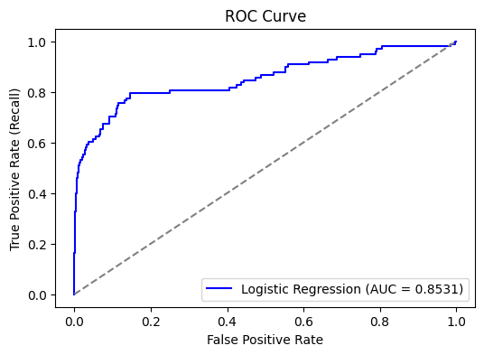

```
AUC: 0.8531
```

```python
fpr, tpr, _ = roc_curve(y_test, probs)
roc_auc = auc(fpr, tpr)
plt.figure(figsize=(6, 4))
plt.plot(fpr, tpr, color='blue', label=f'Logistic Regression (AUC = {roc_auc:.4f})')
plt.plot([0, 1], [0, 1], color='grey', linestyle='--')
plt.xlabel('False Positive Rate')
plt.ylabel('True Positive Rate (Recall)')
plt.title('ROC Curve')
plt.legend(loc="lower right")
plt.show()

print(f"AUC: {roc_auc:.4f}")
```

- AUC-ROC (0.8531) indicates good but not excellent discrimination between fraud and non-fraud cases.
- The model ranks fraud cases (Class = 1) higher than non-fraud cases 85.31% of the time, which is a decent performance.
8. KNN and SVM classification (Performance Comparison)

i. knn model

```python
knn = KNeighborsClassifier()
knn.fit(X_train,y_train)
```

```
KNeighborsClassifier()
```

```python
y_pred = knn.predict(X_test)

# Performance Metrics
metrics2 = {
    "Accuracy": accuracy_score(y_test, y_pred),
    "Precision": precision_score(y_test, y_pred),
    "Recall": recall_score(y_test, y_pred),
    "F1-Score": f1_score(y_test, y_pred)
}

for metric, value in metrics2.items():
    print(f"{metric}: {value:.4f}")
```

```
Accuracy: 0.9988
Precision: 0.7385
Recall: 0.4898
F1-Score: 0.5890
```

ii. SVM Model

```python
svm = SVC()
svm.fit(X_train,y_train)
```

```
SVC()
```

```python
y_pred = svm.predict(X_test)

# Performance Metrics
metrics3 = {
    "Accuracy": accuracy_score(y_test, y_pred),
    "Precision": precision_score(y_test, y_pred),
    "Recall": recall_score(y_test, y_pred),
    "F1-Score": f1_score(y_test, y_pred)
}

for metric, value in metrics3.items():
    print(f"{metric}: {value:.4f}")
```

```
Accuracy: 0.9986
Precision: 0.9545
Recall: 0.2143
F1-Score: 0.3500
```

```python
metrics_df = pd.DataFrame([metrics1, metrics2, metrics3], index=["LR Model", "KNN Model", "SVM Model"])
metrics_df
```

|  | Accuracy | Precision | Recall | F1-Score |
| --- | --- | --- | --- | --- |
| LR Model | 0.998402 | 0.818182 | 0.091837 | 0.165138 |
| KNN Model | 0.998824 | 0.738462 | 0.489796 | 0.588957 |
| SVM Model | 0.998631 | 0.954545 | 0.214286 | 0.350000 |

- The KNN model has the best recall (0.4898) and F1-score (0.5890), making it the most effective at detecting fraud.
- The SVM model has the highest precision (0.9545) but a low recall (0.2143), meaning it identifies fraud cases accurately but misses many.
- The Logistic Regression (LR) model has balanced precision (0.8182) but the lowest recall (0.0918), making it the weakest at detecting fraud cases. KNN is the best overall due to its higher recall and F1-score.